# Project Presenatation

Taylor Mattia

December 6, 2017

## Project Goals:

- Construct county-to-county migration data sets from preexisting census data and county covariate information
- Create spatial visualizations of this migration
- Estimate summary statistics for the network including centrality measures (to see if some counties are more important than others), in-and-out degrees for specific counties, and the degree distribution of the entire network
- Determine whether particular county-covariates, including median income, unemployment, educational attainment, poverty rates, and racial demographic information, can accurately predict the formation of county-to-county migratory networks

## Example: County-to-County Migration between 2011 and 2015

The structure of the data is as follows:

```
##   sendfips recfips movers
## 1     1003    1001     54
## 2     1005    1001      6
## 3     1009    1001      3
## 4     1011    1001      7
## 5     1013    1001      4
## 6     1017    1001      2
```

First, I created a network from the edgelist where each edge is weighted by the number of people who moved from County A (sending county) to County B (receiving county) between 2011 and 2015:

```r
edgelist_states1115 <- as.matrix(migration_1115)
graph_states1115 = graph.edgelist(edgelist_states1115[,1:2], directed=T)
E(graph_states1115)$weight = as.numeric(edgelist_states1115[,3])
```

I also added the following covariate information as vertex attributes from the U.S. Census, measured at the county level:

- Location descriptors (county and state name, latitude, and longitude)
- Household income (2009 - 2015)
- High school graduation rates (2009-2015)
- Household poverty rates (2009-2015)
- Unemployment rate (2009 - 2015)
- Total population (2010 - 2015)
- County-level populations by race (2010 - 2015)

After I construct the data in this manner, I can visualize the data in a number of ways:

1. Within state migration (e.g. Texas)

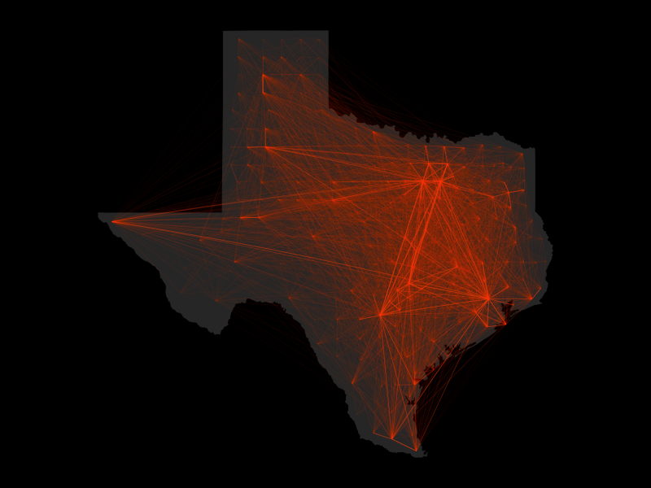

```r
# Plot a map of the united states:
map("state", region="texas", col="grey20", fill=TRUE, bg="black", lwd=0.1)

#Generating color gradient for edges in the network
col.1 <- adjustcolor("orange red", alpha=0.4)
col.2 <- adjustcolor("orange", alpha=0.4)
edge.pal <- colorRampPalette(c(col.1, col.2), alpha = TRUE)
edge.col <- edge.pal(100)

#Generating "arcs" between each pair of coordinates
for(i in 1:nrow(states1115_texas_complete))  {
  node1 <- county_covariate[county_covariate$sendfips == states1115_texas_complete[i,]$sendfips,]
  node2 <- county_covariate[county_covariate$sendfips == states1115_texas_complete[i,]$recfips,]

  arc <- gcIntermediate( c(node1[1,]$Longitude, node1[1,]$Latitude),
                         c(node2[1,]$Longitude, node2[1,]$Latitude),
                         n=100, addStartEnd=TRUE )
  edge.ind <- round(25*states1115_texas_complete[i,]$movers / max(states1115_texas_complete$movers))

  lines(arc, col=edge.col[edge.ind], lwd=edge.ind/30)
}
```

2. Migration to a particular location (i.e. Colorado)

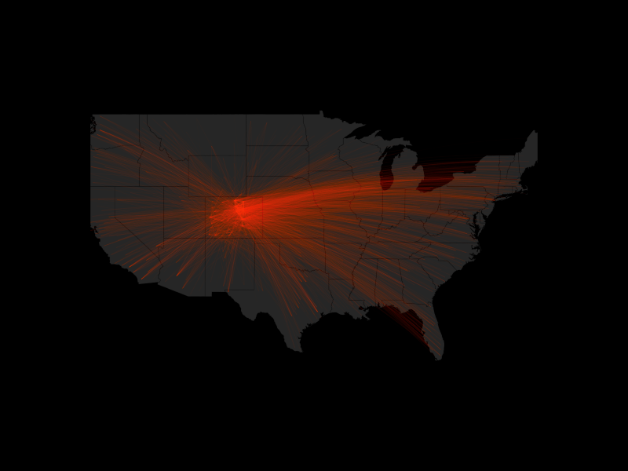

3. Migration from a particular location (i.e. New York City)

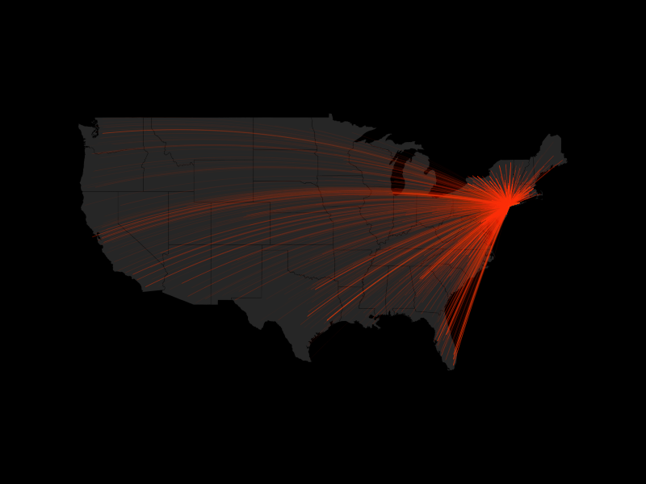

## Summary Statistics (total migration)

1. Number of Degrees (number of people who moved in and out of a country):

```r
degree_weighted <- strength(graph_states1115)
```

```r
head(dplyr::arrange(degree_weighted_data, desc(degree_weighted)), n = 10)
```

```
##    degree_weighted     node_county_names node_state_names
## 1           518973    Los Angeles County               CA
## 2           344433           Cook County               IL
## 3           329260         Harris County               TX
## 4           328300       Maricopa County               AZ
## 5           265779      San Diego County               CA
## 6           244668         Dallas County               TX
## 7           231060         Orange County               CA
## 8           224610       New York County               NY
## 9           210670 San Bernardino County               CA
## 10          209982      Riverside County               CA
```

2. Number of In Degrees (number of people who moved into a county):

```r
in_degree_weighted <-strength(graph_states1115, mode=c("in"))
```

```r
head(dplyr::arrange(in_degree_weighted_data, desc(in_degree_weighted)), n = 10)
```

```
##    in_degree_weighted     node_county_names node_state_names
## 1              214019    Los Angeles County               CA
## 2              170622       Maricopa County               AZ
## 3              164715         Harris County               TX
## 4              140112           Cook County               IL
## 5              116646      San Diego County               CA
## 6              113392      Riverside County               CA
## 7              112609         Dallas County               TX
## 8              109888         Orange County               CA
## 9              109425 San Bernardino County               CA
## 10             107177           King County               WA
```

3. Number of Out Degrees (number of people who moved out of a county):

```r
out_degree_weighted <-strength(graph_states1115, mode=c("out"))
```

```r
head(dplyr::arrange(out_degree_weighted_data, desc(out_degree_weighted)), n = 10)
```

```
##    out_degree_weighted  node_county_names node_state_names
## 1               304954 Los Angeles County               CA
## 2               204321        Cook County               IL
## 3               164545      Harris County               TX
## 4               157678    Maricopa County               AZ
## 5               149133   San Diego County               CA
## 6               132059      Dallas County               TX
## 7               121172      Orange County               CA
## 8               120911       Kings County               NY
## 9               120306    New York County               NY
## 10              101806        King County               WA
```

4. Eigenvector Centrality

```r
eigen_centrality <- eigen_centrality(graph_states1115, directed=T, weights=E(graph_states1115)$weight)$vector
```

```
##    eigen_centrality     node_county_names node_state_names
## 1         1.0000000    Los Angeles County               CA
## 2         0.9229231 San Bernardino County               CA
## 3         0.8884573      Riverside County               CA
## 4         0.8531483         Orange County               CA
## 5         0.4692977      San Diego County               CA
## 6         0.3299657          Clark County               NV
## 7         0.2930472       Maricopa County               AZ
## 8         0.2416759           Kern County               CA
## 9         0.2169155        Alameda County               CA
## 10        0.1907916        Ventura County               CA
```

5. Degree Prestige (receiving many ties from other counties)

```r
net_migration_states1115 <-intergraph::asNetwork(graph_states1115, ignore.eval=FALSE,
                                                 names.eval='weight')

degree_prestige <- sna::prestige(net_migration_states1115, cmode="indegree")
```

```
##    degree_prestige  node_county_names node_state_names
## 1              990    Maricopa County               AZ
## 2              807 Los Angeles County               CA
## 3              797        Cook County               IL
## 4              774   San Diego County               CA
## 5              759      Harris County               TX
## 6              731       Bexar County               TX
## 7              693    Richland County               SC
## 8              688       Clark County               NV
## 9              675      Dallas County               TX
## 10             638     Tarrant County               TX
```

6. Rank prestige (sum of prestige of neighbors)

```r
rank_presitge <- sna::prestige(net_migration_states1115, cmode="eigenvector")
```

```
##    rank_presitge  node_county_names node_state_names
## 1     0.10122722    Maricopa County               AZ
## 2     0.09580173 Los Angeles County               CA
## 3     0.09193649   San Diego County               CA
## 4     0.09171323        Cook County               IL
## 5     0.08769572      Harris County               TX
## 6     0.08559893       Bexar County               TX
## 7     0.08362144       Clark County               NV
## 8     0.08280435    Richland County               SC
## 9     0.08047003      Dallas County               TX
## 10    0.07891234        King County               WA
```

## Summary statistics (migration per capita)

While looking at aggregate migration is helpful, it is also useful to know how many people are moving from County A to County B as a function of the number of people who live in each county (migration per capita):

1. Total Degree

```r
head(dplyr::arrange(degree_per_capita_data, desc(degree_per_capita_weighted)), n = 10)
```

```
##    degree_per_capita_weighted     node_county_names node_state_names
## 1                        2187        Laurens County               GA
## 2                        1916      Jefferson County               AL
## 3                        1913 San Bernardino County               CA
## 4                        1776           Bond County               IL
## 5                        1774         DeKalb County               AL
## 6                        1550        Orleans Parish               LA
## 7                        1489         Greene County               IN
## 8                        1487     Washington County               MS
## 9                        1400        Manatee County               FL
## 10                       1297        Clinton County               MI
```

2. In Degree

```r
head(dplyr::arrange(in_degree_per_capita_data, desc(in_degree_per_capita_weighted)), n = 10)
```

```
##    in_degree_per_capita_weighted     node_county_names node_state_names
## 1                            990        Laurens County               GA
## 2                            807      Jefferson County               AL
## 3                            797 San Bernardino County               CA
## 4                            774           Bond County               IL
## 5                            759         DeKalb County               AL
## 6                            731         Greene County               IN
## 7                            693           Polk County               GA
## 8                            688        Orleans Parish               LA
## 9                            675     Washington County               MS
## 10                           638        Manatee County               FL
```

3. Out Degree

```r
head(dplyr::arrange(out_degree_per_capita_data, desc(out_degree_per_capita_weighted)), n = 10)
```

```
##    out_degree_per_capita_weighted     node_county_names node_state_names
## 1                            1197        Laurens County               GA
## 2                            1116 San Bernardino County               CA
## 3                            1109      Jefferson County               AL
## 4                            1015         DeKalb County               AL
## 5                            1002           Bond County               IL
## 6                             862        Orleans Parish               LA
## 7                             812     Washington County               MS
## 8                             762        Manatee County               FL
## 9                             758         Greene County               IN
## 10                            710     St. Landry Parish               LA
```

4. Eigenvector Centrality

```r
eigen_centrality_pc <- eigen_centrality(graph_states1115_per_capita, directed=T, weights=E(graph_states1115_per_capita)$weight)$vector
```

```
##    eigen_centrality_pc     node_county_names node_state_names
## 1            1.0000000        Laurens County               GA
## 2            0.9464028      Jefferson County               AL
## 3            0.9082190           Bond County               IL
## 4            0.9060135 San Bernardino County               CA
## 5            0.8663255         DeKalb County               AL
## 6            0.8456118         Greene County               IN
## 7            0.8260766        Orleans Parish               LA
## 8            0.8180048           Polk County               GA
## 9            0.7949445     Washington County               MS
## 10           0.7795565         Putnam County               FL
```

5. Degree Prestige (receiving many ties from other counties)

```r
degree_prestige_pc <- sna::prestige(net_migration_pc_states1115, cmode="indegree")
```

```
##    degree_prestige_pc     node_county_names node_state_names
## 1                 990        Laurens County               GA
## 2                 807      Jefferson County               AL
## 3                 797 San Bernardino County               CA
## 4                 774           Bond County               IL
## 5                 759         DeKalb County               AL
## 6                 731         Greene County               IN
## 7                 693           Polk County               GA
## 8                 688        Orleans Parish               LA
## 9                 675     Washington County               MS
## 10                638        Manatee County               FL
```

6. Rank prestige (sum of prestige of neighbors)

```r
rank_presitge_pc <- sna::prestige(net_migration_pc_states1115, cmode="eigenvector")
```

```
##    rank_presitge_pc     node_county_names node_state_names
## 1        0.10122722        Laurens County               GA
## 2        0.09580173      Jefferson County               AL
## 3        0.09193649           Bond County               IL
## 4        0.09171323 San Bernardino County               CA
## 5        0.08769572         DeKalb County               AL
## 6        0.08559893         Greene County               IN
## 7        0.08362144        Orleans Parish               LA
## 8        0.08280435           Polk County               GA
## 9        0.08047003     Washington County               MS
## 10       0.07891234         Putnam County               FL
```

## P1 Model

I am interested to see if the observed network can be predicted based on observable covariates. In particular, I am interested to see whether county covariates themselves can predict where people move to and from. Because of the size of the 2011-2015 migration, I chose to estimate a P1 Model that looks at migration to and from all counties in Texas. For each sending and receiving county, I have nodal covariate information on unemployment (% of people over the age of 16 who are actively seeking work but cannot find it), high school graduation rates, percentage of people in each county that identify as white and Latino, and median household income for the year 2010. Therefore, I am interested in whether information at time $t-1$ can predict migration in time $t$. In doing so, I attempt to test the following hypotheses:

- H1: The higher a county’s unemployment rate, the more outward migration a county will experience (and vice versa for lower unemployment rates)
- H2: The higher a county’s median household income, the more indward migration a county will experience (and vice versa for lower median incomes)
- H3: The lower a county’s high school graduation rate, the more outward migration a county will experience (and vice versa for higher high school graduation rates)
- H4: I have no strong prior assumption as to why counties with a higher percentage of white or Latino residents would experience more or less migration. If I had information about the demographic information about the movers, I would feel more comfortable making claims about the relationship between demographic information of the county and inward and outward migration.

# The Data

I first need to manipulate the data such that I have an $n x n$ square adjacency matrix where the rows representing sending counties, the columns represent receiving counties, and the cell value represents the number of people who moved from the sending to receiving county. I begin by loading an object called “network_migration_states1115.RData.” This is a network object that has county to county migration for all counties in all states (excluding Alaska and Hawaii) between 2011 and 2015.

```r
network_1115 <- get(load('net_migration_states1115.RData'))
```

Then, I create an induced subgraph that represents migration to and from all counties in Texas (intra-Texas migration).

```r
# Creating a network of migration within Texas
texas_1115 <- get.inducedSubgraph(network_1115, which(network_1115 %v% 'state_name'=="TX"))

#Creating Adjacency Matrix
states1115_texas_complete <- get(load('states1115_texas_complete.RData'))
texas_adj_matrix <- subset(states1115_texas_complete, select=c("sendfips", "recfips", "movers"))

#Reshaping into long format
texas_adj_matrix <- reshape(texas_adj_matrix, idvar = "sendfips",  timevar="recfips", direction="wide")

#Renaming columns
colnames(texas_adj_matrix) <- gsub("movers.", "", colnames(texas_adj_matrix), fixed = TRUE)

#Making first column the name of the first column
rownames(texas_adj_matrix) <- texas_adj_matrix[,1]
texas_adj_matrix[,1] <- NULL

#Removing counties to make matrix square
texas_adj_matrix <- texas_adj_matrix[!rownames(texas_adj_matrix) %in% c("48269", "48301"), ]
rownames(texas_adj_matrix) <-as.numeric(as.character(rownames(texas_adj_matrix)))

#Reordering matrix by row and column vectors
texas_adj_matrix <- texas_adj_matrix[ order(row.names(texas_adj_matrix)), order(colnames(texas_adj_matrix)) ]
texas_adj_matrix <- as.matrix(texas_adj_matrix)

#Assigning values of 0 to counties that have "NA" values --> meaning there was no movement from county A to county B between 2011 and 2015

texas_adj_matrix[is.na(texas_adj_matrix)] <- 0

#Assigning NA values to diagonals
diag(texas_adj_matrix) <- NA
```

The final adjacency matrix is a 252 x 252 matrix:

```r
head(texas_adj_matrix, n = 2L, addrownums=TRUE)
```

```
##       48001 48003 48005 48007 48009 48011 48013 48015 48017 48019 48021
## 48001    NA   176    76     0     0     0     0     0     0     0   317
## 48003   313    NA     0     0     0     0     0     0     0     0     0
##       48023 48025 48027 48029 48031 48033 48035 48037 48039 48041 48043
## 48001     0   256   313   343     0     0     0   235    77   254     0
## 48003     0     0     0     2     0     0     0     0     0     0     0
##       48045 48047 48049 48051 48053 48055 48057 48059 48061 48063 48065
## 48001     0     0    20     0   250   266     0     0     0     0     0
## 48003     0     0     0     0     0     0     0     0     0     0     0
##       48067 48069 48071 48073 48075 48077 48079 48081 48083 48085 48087
## 48001     0     0   313   354     0     0   234     0     0     0     0
## 48003     0     0     0     0     0     0     0     0     0    90     0
##       48089 48091 48093 48095 48097 48099 48101 48103 48105 48107 48109
## 48001     0     0     0     0     0   120     0     0     0     0     0
## 48003     0     0    43   189     0     0     0     0     0     0     0
```

[output cut: 54 more lines]

Next, I create a sender and receiver matrix:

```r
#Creating a unique id for each sender and receiver
n <- nrow(texas_adj_matrix)

#2) Senders and Receivers
senders <- c(matrix((as.numeric(rownames(texas_adj_matrix))), n, n))

receivers <- c(t(matrix((as.numeric(rownames(texas_adj_matrix))), n, n)))
```

Then, I extract the outcome variable (weighted edges from sender to receiver county)

```r
y <- c(texas_adj_matrix)
```

```r
#Senders
head(senders, n = 10)
```

```
##  [1] 48001 48003 48005 48007 48009 48011 48013 48015 48017 48019
```

```r
#Receivers
head(receivers, n = 10)
```

```
##  [1] 48001 48001 48001 48001 48001 48001 48001 48001 48001 48001
```

```r
#Weighted edges
head(y, n = 10)
```

```
##  [1]  NA 313 112 120   0   0   0 349   0   0
```

I then do the same process to create lists with length $ = n^{n}$ for each covariate for both sending and receiving counties. The example shown is the data cleaning and manipulation process for county unemployment. The same pattern was extended for the other covariates of interest.

First, I extracted the county unemployment information from the dataset containing covariates.

```r
# Extracting unemployment at time t-1 (2010) from county covariate data set
texas_1115_unemployment <- subset(states1115_texas_complete, select=c("sendfips", "unemploymentrate_2010"))
texas_1115_unemployment <- unique(texas_1115_unemployment)
```

Then, I created an $n^{n}$ (where n = the total number of counties in the data set) list of unemployment rates, which I matched with the list of “senders” based on unique county id’s that were assigned using state and county FIPS codes.

```r
# Sending county unemployment
senders_unemployment <- as.matrix(senders)
senders_unemployment <- as.data.frame(senders_unemployment)
colnames(senders_unemployment) <- c("sendfips")

#Merging the datasets
texas_unemployment_matrix_s <- join(senders_unemployment, texas_1115_unemployment, by = "sendfips")

#Reshaping for analysis
texas_senders_umemployment <- texas_unemployment_matrix_s$unemploymentrate_2010
texas_senders_umemployment <- as.numeric(texas_senders_umemployment)
```

This same process was undertaken for receiving counties.

```r
#Receiving county unemployment
receivers_unemployment <- as.matrix(receivers)
receivers_unemployment <- as.data.frame(receivers_unemployment)
colnames(receivers_unemployment) <- c("sendfips")

#Merging the data sets
texas_unemployment_matrix_r <- join(receivers_unemployment, texas_1115_unemployment, by =c("sendfips"))

#Reshaping for analysis
texas_receivers_umemployment <- texas_unemployment_matrix_r$unemploymentrate_2010
texas_receivers_umemployment <- as.numeric(texas_receivers_umemployment)
```

The sending and receiving county lists look as follows:

```r
#Senders unemployment
head(senders, n = 10)
```

```
##  [1] 48001 48003 48005 48007 48009 48011 48013 48015 48017 48019
```

```r
head(texas_senders_umemployment, n = 10)
```

```
##  [1] 7.0 5.6 6.2 6.8 3.0 2.8 9.5 5.5 4.0 4.9
```

```r
#Receiveres unemployment
head(receivers, n = 10)
```

```
##  [1] 48001 48001 48001 48001 48001 48001 48001 48001 48001 48001
```

```r
head(texas_receivers_umemployment, n = 10)
```

```
##  [1] 7 7 7 7 7 7 7 7 7 7
```

The same process was done for sending and receiving counties for the remaining covariates of interest (percentage of residents in the county that identify as white and Latino, median household income, and high school graduation rates).

I then estimated a Poisson count model to see whether any of the covariates of interest increase or decrease the likelihood of migration from a sending county to a receiving county:

```r
model1 <- glm(y ~ texas_senders_umemployment + texas_receivers_umemployment + texas_senders_perc_white
            + texas_receivers_perc_white + texas_senders_grad_rate + texas_receivers_grad_rate +
            + texas_senders_hh_income + texas_receivers_hh_income +
           + texas_senders_perc_latino + texas_receivers_perc_latino , family="poisson")

summary(model1)
```

```
##
## Call:
## glm(formula = y ~ texas_senders_umemployment + texas_receivers_umemployment +
##     texas_senders_perc_white + texas_receivers_perc_white + texas_senders_grad_rate +
##     texas_receivers_grad_rate + +texas_senders_hh_income + texas_receivers_hh_income +
##     +texas_senders_perc_latino + texas_receivers_perc_latino,
##     family = "poisson")
##
## Deviance Residuals:
##     Min       1Q   Median       3Q      Max
## -44.637   -8.062   -6.472   -4.935  128.758
##
## Coefficients:
##                                Estimate Std. Error z value Pr(>|z|)
## (Intercept)                   9.518e+00  1.021e-02   932.1   <2e-16 ***
## texas_senders_umemployment    4.447e-02  3.040e-04   146.3   <2e-16 ***
## texas_receivers_umemployment  4.368e-02  3.034e-04   144.0   <2e-16 ***
## texas_senders_perc_white     -2.811e-02  7.959e-05  -353.2   <2e-16 ***
## texas_receivers_perc_white   -2.996e-02  7.855e-05  -381.5   <2e-16 ***
## texas_senders_grad_rate      -2.205e-02  7.107e-05  -310.2   <2e-16 ***
## texas_receivers_grad_rate    -2.262e-02  7.080e-05  -319.5   <2e-16 ***
## texas_senders_hh_income       1.676e-06  2.277e-09   736.1   <2e-16 ***
## texas_receivers_hh_income     1.501e-06  2.405e-09   624.0   <2e-16 ***
## texas_senders_perc_latino    -5.146e-03  3.233e-05  -159.2   <2e-16 ***
## texas_receivers_perc_latino  -7.352e-03  3.292e-05  -223.3   <2e-16 ***
## ---
## Signif. codes:  0 '***' 0.001 '**' 0.01 '*' 0.05 '.' 0.1 ' ' 1
##
## (Dispersion parameter for poisson family taken to be 1)
##
##     Null deviance: 10554851  on 62749  degrees of freedom
## Residual deviance:  8278525  on 62739  degrees of freedom
##   (754 observations deleted due to missingness)
## AIC: 8344694
##
## Number of Fisher Scoring iterations: 8
```

Based on the results of the model, it is difficult to assess whether any given covariate is a good predictor of county to county migration for both sending and receiving counties. In the future, it would be useful to randomly sample edges from the network and conduct inference in that manner, as the size of the network is so large that every predictor will appear “significant”.